# Estadística y Probabilidad Aplicada

Josue Emmanuel Jauregui Arvilla

1 de Noviembre de 2025

# 1 Introducción

El siguiente reporte técnico presenta un análisis de los datos de marginación municipal correspondientes al año 2020, publicados por el Consejo Nacional de Población (CONAPO). En este estudio se aplican diversas medidas de tendencia central y de dispersión con el propósito de identificar cuáles estados y municipios presentan mayores o menores niveles de vulnerabilidad social. Además, se incluyen ejercicios de distribución de probabilidad que permiten estimar la ocurrencia de eventos favorables dentro de un espacio determinado.

# 2 Preparación de datos

```r
# Librería para cargar archivos excel
library(readxl)

# Librería para generar gráficos de correlación
library(corrplot)
# Librería para generar gráficos de densidad
library(car)
# marginacion <- read_excel("C:\\Users\\a0487048\\Documents\\TI Josue Documents\\Projects\\Python\\Estadistica_Ciencia_de_Datos\\data\\IMM_2020.xlsx", sheet = "IMM_2020") # Archivo si corre en Windows
marginacion <- read_excel("/Users/jaureperro/PycharmProjects/Estadistica_Ciencia_de_Datos/data/IMM_2020.xlsx", sheet = "IMM_2020") # Archivo si corre en Mac OS
sapply(marginacion, class) # Obtenemos los tipos de datos de cada columna
```

```
##     CVE_ENT     NOM_ENT     CVE_MUN     NOM_MUN     POB_TOT       ANALF
## "character" "character" "character" "character"   "numeric"   "numeric"
##       SBASC       OVSDE       OVSEE       OVSAE        OVPT        VHAC
##   "numeric"   "numeric"   "numeric"   "numeric"   "numeric"   "numeric"
##     PL.5000       PO2SM     IM_2020     GM_2020    IMN_2020
##   "numeric"   "numeric"   "numeric" "character"   "numeric"
```

Con base en los tipos de datos de cada columna, se observa que las variables “CVE_ENT” y “CVE_MUN” son de tipo character, lo que indica que contienen cadenas de texto. Sin embargo, para su correcto tratamiento y análisis numérico, es necesario convertirlas al tipo numérico mediante una transformación de datos.

```r
marginacion$CVE_ENT <- as.numeric(marginacion$CVE_ENT) # Conversión CVE_ENT
marginacion$CVE_MUN <- as.numeric(marginacion$CVE_MUN) # Conversión CVE_MUN
table(marginacion$CVE_ENT) # Cantidad de municipios por entidad
```

```
##
##   1   2   3   4   5   6   7   8   9  10  11  12  13  14  15  16  17  18  19  20
##  11   6   5  12  38  10 124  67  16  39  46  81  84 125 125 113  36  20  51 570
##  21  22  23  24  25  26  27  28  29  30  31  32
## 217  18  11  58  18  72  17  43  60 212 106  58
```

```r
marginacion
```

```
## # A tibble: 2,469 × 17
##    CVE_ENT NOM_ENT   CVE_MUN NOM_MUN POB_TOT ANALF SBASC OVSDE OVSEE OVSAE  OVPT
##      <dbl> <chr>       <dbl> <chr>     <dbl> <dbl> <dbl> <dbl> <dbl> <dbl> <dbl>
##  1       1 Aguascal…    1001 Aguasc…  948990  1.64  20.4 0.105 0.113 0.379 0.591
##  2       1 Aguascal…    1002 Asient…   51536  3.53  33.9 2.65  0.486 0.858 1.35
##  3       1 Aguascal…    1003 Calvil…   58250  4.49  42.5 0.365 0.517 0.801 1.04
##  4       1 Aguascal…    1004 Cosío     17000  3.14  27.7 0.713 0.577 0.660 1.03
##  5       1 Aguascal…    1005 Jesús …  129929  2.38  26.7 0.277 0.355 0.860 1.31
##  6       1 Aguascal…    1006 Pabell…   47646  2.73  25.7 0.541 0.425 1.04  0.706
##  7       1 Aguascal…    1007 Rincón…   57369  3.45  27.1 0.966 0.501 1.03  1.30
##  8       1 Aguascal…    1008 San Jo…    9552  2.44  28.4 2.11  0.923 1.71  0.860
##  9       1 Aguascal…    1009 Tepeza…   22485  4.24  35.1 1.39  0.585 1.09  1.43
## 10       1 Aguascal…    1010 El Lla…   20853  3.90  34.8 2.32  1.03  1.78  1.45
## # ℹ 2,459 more rows
## # ℹ 6 more variables: VHAC <dbl>, PL.5000 <dbl>, PO2SM <dbl>, IM_2020 <dbl>,
## #   GM_2020 <chr>, IMN_2020 <dbl>
```

# 3 Análisis de tendencia central y dispersión

Una vez verificado que la base de datos contiene correctamente las 32 entidades federativas y el número total de municipios correspondiente, se procede a realizar el análisis de tendencia central (media y mediana) y de dispersión (desviación estándar) sobre las variables: ANALF, SBASC, OVSDE, OVSEE, OVSAE, OVPT, VHAC, PL.5000 y PO2SM.

A continuación, se presenta una tabla con el significado de cada variable, la cual servirá de referencia para los análisis posteriores.

ANALF - Porcentaje de población de 15 años o más analfabeta  
SBASC - Porcentaje de población de 15 años o más sin educación básica  
OVSDE - Porcentaje de ocupantes en viviendas particulares habitadas sin drenaje ni excusado  
OVSEE - Porcentaje de ocupantes en viviendas particulares habitadas sin energía eléctrica  
OVSAE - Porcentaje de ocupantes en viviendas particulares habitadas sin agua entubada  
OVPT - Porcentaje de ocupantes en viviendas particulares habitadas con piso de tierra  
VHAC - Porcentaje de viviendas particulares con hacinamiento  
PL.5000 - Porcentaje de población que vive en localidades menores a 5 000 habitantes  
PO2SM - Porcentaje de población ocupada con ingresos de hasta 2 salarios mínimos  
IM_2020 - Índice de marginación, 2020  
IMN_2020 - Índice de marginación normalizado, 2020

```r
# Función para obtener el rango, rango intercuantílico, media, mediana y la desviación estándar de cada variables mencionadas anteriormente
medidas <- function(x) {
  c(rango = diff(range(x)), iqr = IQR(x), media = mean(x), mediana = median(x), desviacion_estandar = sd(x))
}

resultado <- aggregate(cbind(ANALF, SBASC, OVSDE, OVSEE, OVSAE, OVPT, VHAC, PL.5000, PO2SM) ~ NOM_ENT, FUN = medidas, data = marginacion)
resultado
```

```
##                            NOM_ENT ANALF.rango  ANALF.iqr ANALF.media
## 1                   Aguascalientes   2.8467713  1.3022332   3.1180489
## 2                  Baja California   6.6522965  0.5219906   2.9129114
## 3              Baja California Sur   2.3698817  1.9615233   2.8709501
## 4                         Campeche   9.8915295  1.5745285   8.1909867
## 5                          Chiapas  36.3398698  9.5613055  16.4025289
## 6                        Chihuahua  44.5056334  4.6202586   7.4807926
## 7                 Ciudad de México   2.4167780  0.6459909   1.4217906
## 8             Coahuila de Zaragoza   6.2343178  1.8262071   2.8712038
## 9                           Colima   6.0444385  4.1852686   4.5903714
## 10                         Durango  21.4656473  2.3002394   4.6514461
## 11                      Guanajuato  11.3059085  3.1697310   7.6382403
## 12                        Guerrero  47.8047606  8.6552876  17.7342564
## 13                         Hidalgo  25.5192718  9.6464085   9.3436485
## 14                         Jalisco  23.2207970  3.0407077   5.7854024
```

[output cut: 315 more lines]

# 4 Análisis de gráfico de correlación

Para analizar cómo se relacionan las variables entre sí, se genera un gráfico de correlación que permite visualizar el grado y la dirección de asociación entre las variables ANALF, SBASC, OVSDE, OVSEE, OVSAE, OVPT, VHAC, PL.5000 y PO2SM.

```r
#Obtenemos el dataframe con las variables deseadas
marginacion_filtered <- marginacion[, c("ANALF", "SBASC", "OVSDE", "OVSEE", "OVSAE", "OVPT", "VHAC", "PL.5000", "PO2SM")]

# Matriz de correlacion - Pearson
# Creamos la matriz de correlación
matriz_correlacion <- cor(marginacion_filtered)
matriz_correlacion <- round(matriz_correlacion, 2) # Se redujo la tabla de decimales a solo 2 decimales para que sea más fácil de leer
matriz_correlacion # Valores de la matriz de correlación
```

```
##         ANALF SBASC OVSDE OVSEE OVSAE OVPT VHAC PL.5000 PO2SM
## ANALF    1.00  0.78  0.35  0.35  0.36 0.64 0.66    0.45  0.62
## SBASC    0.78  1.00  0.26  0.30  0.27 0.55 0.52    0.60  0.70
## OVSDE    0.35  0.26  1.00  0.53  0.22 0.28 0.37    0.21  0.20
## OVSEE    0.35  0.30  0.53  1.00  0.34 0.50 0.31    0.23  0.20
## OVSAE    0.36  0.27  0.22  0.34  1.00 0.39 0.32    0.19  0.28
## OVPT     0.64  0.55  0.28  0.50  0.39 1.00 0.62    0.34  0.48
## VHAC     0.66  0.52  0.37  0.31  0.32 0.62 1.00    0.27  0.58
## PL.5000  0.45  0.60  0.21  0.23  0.19 0.34 0.27    1.00  0.58
## PO2SM    0.62  0.70  0.20  0.20  0.28 0.48 0.58    0.58  1.00
```

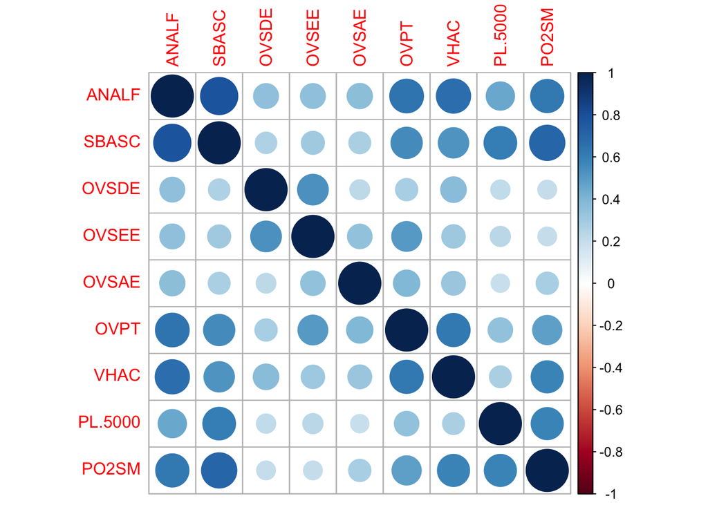

```r
# Generemos gráfico de correlación
corrplot(matriz_correlacion)
```

A partir de la matriz de correlación, se observa que no existen valores negativos, lo cual indica que todas las variables presentan una relación positiva entre sí. Esto significa que, en general, cuando una variable aumenta, las demás tienden a aumentar también.

Al observar el diagrama de correlación correspondiente a la variable ANALF (porcentaje de población de 15 años o más analfabeta), se aprecia una correlación positiva significativa con las variables SBASC (porcentaje de poblacion de 15 años o más sin educación básica), OVPT (porcentaje de ocupantes en viviendas particulares habitadas con piso de tierra) y VHAC (porcentaje de viviendas particulares con hacimiento), con coeficientes de 0.78, 0.64 y 0.66, respectivamente.

Esto indica que a medida que aumenta el porcentaje de población sin educación básica, también incrementa el número de personas analfabetas, lo cual es coherente con la relación directa entre el acceso a la educación y el nivel de alfabetización.

Asimismo, la correlación positiva entre ANALF y las variables OVPT y VHAC sugiere que en los contextos donde existe una mayor proporción de personas analfabetas, también tiende a haber más viviendas con condiciones precarias, como pisos de tierra o situaciones de hacinamiento.

Por otra parte, se observa que la variable SBASC (población sin educación básica) presenta una fuerte correlación positiva con la variable PO2SM (porcentaje de población ocupada con ingresos de hasta dos salarios mínimos) de 0.70.

Esta relación indica que en los municipios o entidades donde existe un mayor porcentaje de población con bajo nivel educativo, también tiende a concentrarse una mayor proporción de trabajadores con ingresos bajos. En otras palabras, la falta de educación básica se asocia con menores oportunidades laborales y salarios reducidos.

Por otra parte, se observa que la variable OVSDE (porcentaje de ocupantes en viviendas particulares habitadas sin drenaje ni excusado) presenta una correlación positiva de 0.53 con la variable OVSEE (porcentaje de ocupantes en viviendas particulares habitadas sin energía eléctrica).

Esta relación sugiere que las viviendas que carecen de drenaje y excusado suelen también presentar carencias en el acceso a servicios básicos como la energía eléctrica, lo que refleja una coincidencia de condiciones de rezago habitacional.

En cuanto a la variable OVSAE (porcentaje de ocupantes en viviendas particulares habitadas sin agua entubada), se observan niveles de correlación débiles a moderados, con valores que oscilan entre 0.19 y 0.39 respecto a las demás variables analizadas.

Esto indica que, aunque la carencia de agua entubada puede estar relacionada con otras formas de rezago habitacional o social, dicha relación no es tan fuerte como la observada entre otras variables de servicios básicos.

Otra variable relevante es PL.5000 (porcentaje de población que vive en localidades menores a 5,000 habitantes). En este caso, se observa una correlación positiva con diversas variables de rezago social, entre ellas ANALF (0.45), SBASC (0.60) y PO2SM (0.58).

Estos valores indican que en las localidades con menor número de habitantes tienden a concentrarse mayores proporciones de población analfabeta, personas sin educación básica y trabajadores con ingresos de hasta dos salarios mínimos. En otras palabras, las comunidades más pequeñas muestran una mayor presencia de condiciones de vulnerabilidad educativa y económica, lo cual refleja la desigualdad territorial entre zonas urbanas y rurales.

# 5 Gráfico de correlación del Índice de Marginación Normalizado

A continuación, se genera un gráfico de correlación utilizando la variable IMN_2020, que representa el Índice de Marginación Normalizado para cada municipio.

Es importante recordar que este índice toma valores entre 0 y 1, donde los valores más cercanos a 1 indican mayor marginación y los cercanos a 0 menor marginación.

El análisis se enfoca únicamente en los municipios pertenecientes a los estados de Nuevo León, Durango, Jalisco, Veracruz y Chiapas, con el objetivo de comparar su comportamiento y relación en términos de marginación.

```r
# Set encoding
Sys.setlocale("LC_CTYPE", "en_US.UTF-8") # Windows
```

```
## [1] "en_US.UTF-8"
```

```r
#Filtro entidades federativas de Nuevo León, Durango, Jalisco, Veracruz y Chiapas
filtro_estados <- marginacion$NOM_ENT %in% c("Nuevo León", "Durango", "Jalisco", "Veracruz de Ignacio de la Llave", "Chiapas")
marginacion_estados <- marginacion[filtro_estados,]

# Ordenan los valores por entidad federativa
marginacion_estados <- marginacion_estados[order(marginacion_estados$NOM_ENT),]
aggregate(IMN_2020 ~ NOM_ENT, FUN = length, data = marginacion_estados) # Obtenemos la cantidad de municipios de cada estado para verificar que obtenemos la información de las entidadas deseadas
```

```
##                           NOM_ENT IMN_2020
## 1                         Chiapas      124
## 2                         Durango       39
## 3                         Jalisco      125
## 4                      Nuevo León       51
## 5 Veracruz de Ignacio de la Llave      212
```

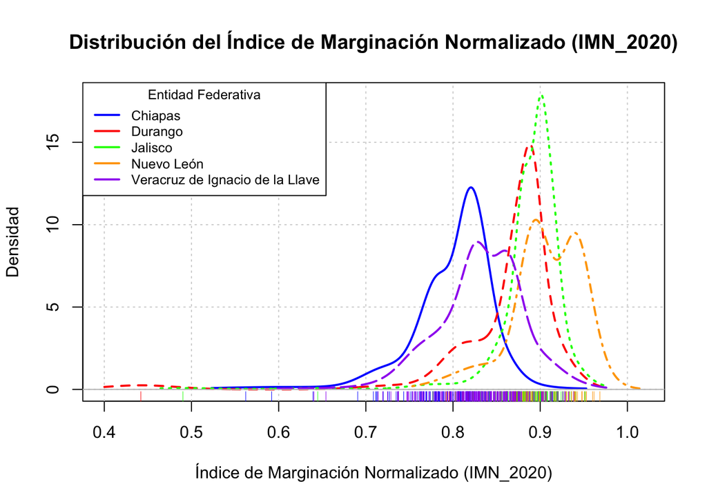

```r
# Asignamos colores para cada entidad federativa
cols <- c("blue", "red", "green", "orange", "purple")

# Generamos el gráfico de densidad en base al Índice de Marginación Normalizado vs Entidad Federativa
densityPlot(IMN_2020 ~ as.factor(NOM_ENT),
            data = marginacion_estados,
            col = cols,
            main = "Distribución del Índice de Marginación Normalizado (IMN_2020)",
            xlab = "Índice de Marginación Normalizado (IMN_2020)",
            ylab = "Densidad",
            legend = FALSE)
legend("topleft",
       legend = unique(marginacion_estados$NOM_ENT),
       title = "Entidad Federativa",
       col = cols,
       lwd = 2,
       cex = 0.8)
```

Chiapas presenta la distribución más desplazada hacia la izquierda, con un pico principal alrededor de 0.83. Esto indica que la mayoría de sus municipios presentan altos niveles de marginación, siendo la entidad con mayor marginación promedio entre las analizadas.

Veracruz muestra una distribución similar a la de Chiapas, aunque ligeramente más concentrada hacia valores cercanos a 0.82 y 0.87. Esto sugiere que también enfrenta niveles de marginación altos, aunque con una menor intensidad que Chiapas.

Además, se observa que la distribución de Veracruz es bimodal, lo que indica la presencia de dos grupos de municipios con diferentes condiciones socioeconómicas: uno con mayor marginación y otro con menor marginación.

Durango tiene su pico alrededor de 0.87, lo que refleja que la mayoría de sus municipios presentan niveles de marginación intermedios, con algunos municipios más rezagados y otros con mejores condiciones.

Jalisco y Nuevo León concentran sus distribuciones hacia la derecha del eje, con valores cercanos a 0.9 y superiores. Esto indica que son los estados con menores niveles de marginación, es decir, mejores condiciones socioeconómicas. En particular, Jalisco presenta una distribución más concentrada, lo que sugiere menor desigualdad interna entre sus municipios.

Nuevo León, al igual que Veracruz, presenta una distribución bimodal, lo que indica la presencia de dos grupos de municipios con diferentes condiciones socioeconómicas: uno con marginación baja y otro con marginación muy baja.

Esto sugiere que, aunque el estado en general presenta buenas condiciones socioeconómicas, existen diferencias internas leves entre sus municipios.

# 6 Tabla resumen de las 32 entidades federativas

A continuación, se presenta una tabla que resume las 32 entidades federativas en función de cada una de las nueve variables (ANALF, SBASC, OVSDE, OVSEE, OVSAE, OVPT, VHAC, PL.5000 y PO2SM), las cuales constituyen la base del Índice de Marginación.

```r
# Obtenemos la tabla de marginación
marginacion_poblacion <- marginacion

# Se crea una columna nueva de cada variable de intéres vs su población actual de cada municipio
marginacion_poblacion$ANALF_QTY <- (marginacion_poblacion$POB_TOT * marginacion_poblacion$ANALF) / 100
marginacion_poblacion$SBASC_QTY <- (marginacion_poblacion$POB_TOT * marginacion_poblacion$SBASC) / 100
marginacion_poblacion$OVSDE_QTY <- (marginacion_poblacion$POB_TOT * marginacion_poblacion$OVSDE) / 100
marginacion_poblacion$OVSEE_QTY <- (marginacion_poblacion$POB_TOT * marginacion_poblacion$OVSEE) / 100
marginacion_poblacion$OVSAE_QTY <- (marginacion_poblacion$POB_TOT * marginacion_poblacion$OVSAE) / 100
marginacion_poblacion$OVPT_QTY <- (marginacion_poblacion$POB_TOT * marginacion_poblacion$OVPT) / 100
marginacion_poblacion$VHAC_QTY <- (marginacion_poblacion$POB_TOT * marginacion_poblacion$VHAC) / 100
marginacion_poblacion$PL.5000_QTY <- (marginacion_poblacion$POB_TOT * marginacion_poblacion$PL.5000) / 100
marginacion_poblacion$PO2SM_QTY <- (marginacion_poblacion$POB_TOT * marginacion_poblacion$PO2SM) / 100

# Se muestra junto a cada variable de interés su cantidad correspondiente respecto a la población total,
marginacion_poblacion[, c(1, 2, 5, 6, 18, 7, 19, 8, 20, 9, 21, 10, 22, 11, 23, 12, 24, 13, 25, 14, 26)]
```

```
## # A tibble: 2,469 × 21
##    CVE_ENT NOM_ENT POB_TOT ANALF ANALF_QTY SBASC SBASC_QTY OVSDE OVSDE_QTY OVSEE
##      <dbl> <chr>     <dbl> <dbl>     <dbl> <dbl>     <dbl> <dbl>     <dbl> <dbl>
##  1       1 Aguasc…  948990  1.64    15608.  20.4   193283. 0.105      995. 0.113
##  2       1 Aguasc…   51536  3.53     1817.  33.9    17474. 2.65      1366. 0.486
##  3       1 Aguasc…   58250  4.49     2616.  42.5    24746. 0.365      213. 0.517
##  4       1 Aguasc…   17000  3.14      535.  27.7     4708. 0.713      121. 0.577
##  5       1 Aguasc…  129929  2.38     3093.  26.7    34681. 0.277      360. 0.355
##  6       1 Aguasc…   47646  2.73     1302.  25.7    12257. 0.541      258. 0.425
##  7       1 Aguasc…   57369  3.45     1977.  27.1    15544. 0.966      554. 0.501
##  8       1 Aguasc…    9552  2.44      233.  28.4     2715. 2.11       201. 0.923
##  9       1 Aguasc…   22485  4.24      952.  35.1     7889. 1.39       311. 0.585
## 10       1 Aguasc…   20853  3.90      813.  34.8     7248. 2.32       484. 1.03
## # ℹ 2,459 more rows
## # ℹ 11 more variables: OVSEE_QTY <dbl>, OVSAE <dbl>, OVSAE_QTY <dbl>,
## #   OVPT <dbl>, OVPT_QTY <dbl>, VHAC <dbl>, VHAC_QTY <dbl>, PL.5000 <dbl>,
## #   PL.5000_QTY <dbl>, PO2SM <dbl>, PO2SM_QTY <dbl>
```

```r
# Realizamos la suma de las cantidades de cada entidad
aggregate(cbind(POB_TOT,
                ANALF_QTY,
                SBASC_QTY,
                OVSDE_QTY,
                OVSEE_QTY,
                OVSAE_QTY,
                OVPT_QTY,
                VHAC_QTY,
                PL.5000_QTY,
                PO2SM_QTY) ~ NOM_ENT, FUN = sum, data = marginacion_poblacion) # 2.13 ags repecto al total de la poblacion
```

```
##                            NOM_ENT  POB_TOT ANALF_QTY SBASC_QTY  OVSDE_QTY
## 1                   Aguascalientes  1425607  30409.14  338193.0   4978.376
## 2                  Baja California  3769020  69637.84  933261.3   7544.482
## 3              Baja California Sur   798447  18703.37  192006.7   3357.589
## 4                         Campeche   928363  55540.13  279215.6  23284.989
## 5                          Chiapas  5543828 788547.56 2719809.4 136013.307
## 6                        Chihuahua  3741869 103987.51 1036329.1  53136.872
## 7                 Ciudad de México  9209944 132796.31 1635049.4   4783.373
## 8             Coahuila de Zaragoza  3146771  52880.06  678081.2   9406.065
## 9                           Colima   731391  24961.86  204623.8   1966.571
## 10                         Durango  1832650  52733.60  509945.3  52619.233
## 11                      Guanajuato  6166934 328318.95 2072813.3 118797.341
## 12                        Guerrero  3540685 458108.09 1532263.7 331671.034
## 13                         Hidalgo  3082841 209341.89  931870.5  58513.398
## 14                         Jalisco  8348151 245816.98 2485911.9  47873.089
```

[output cut: 51 more lines]

# 7 Diagrama de caja

A continuación, se presenta un diagrama de cajas que permite comparar el Índice de Marginación entre los estados de Chiapas, Guerrero, Nuevo León, Tamaulipas y Durango.

```r
# Set encoding
Sys.setlocale("LC_CTYPE", "en_US.UTF-8") # Windows
```

```
## [1] "en_US.UTF-8"
```

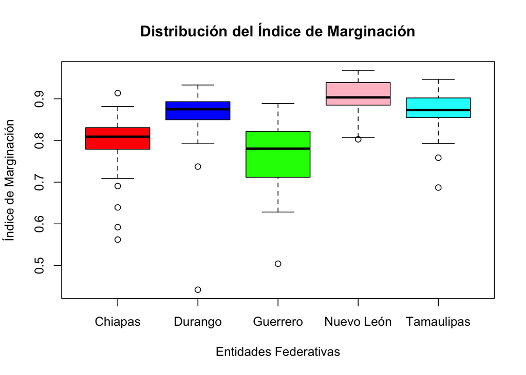

```r
# Filtrado de estados
filtro_estados <- marginacion$NOM_ENT %in% c("Chiapas", "Guerrero", "Nuevo León", "Tamaulipas", "Durango")
marginacion_estados <- marginacion[filtro_estados,]

# Generación de diagrama de boxplot
boxplot(IMN_2020 ~ NOM_ENT,
        data = marginacion_estados,
        main = "Distribución del Índice de Marginación",
        xlab = "Entidades Federativas",
        ylab = "Índice de Marginación",
        col = c("red", "blue", "green", "pink", "cyan"))
```

A partir del gráfico de cajas podemos observar que Guerrero es la entidad federativa con el mayor índice de marginación. Esto se evidencia tanto en la posición de la mediana como en el tamaño de la caja, que reflejan una mayor dispersión y un nivel de marginación alto en la mayoría de su población.

Por el contrario, Nuevo León presenta el índice de marginación más bajo (cercano a 1) en comparación con las demás entidades. Esto sugiere que la población del estado goza de mejores condiciones en educación, vivienda, ingresos, servicios básicos y ubicación geográfica.

En el caso de Durango, se observa un índice de marginación predominantemente bajo, aunque existen zonas con niveles medios y altos. Esto se aprecia tanto en la mediana como en la amplitud de la caja. Asimismo, destacan algunos valores atípicos, entre los cuales se encuentra el municipio de Mezquital, con un índice de marginación de 0.44, considerado extremadamente alto en comparación con el resto del estado.

Finalmente, Tamaulipas se posiciona como el segundo estado con menor índice de marginación. Esto se puede observar en el tercer cuartil del gráfico, donde la mediana se sitúa alrededor de 0.88. La mayoría de la población presenta niveles de marginación bajos o muy bajos, aunque existen excepciones en algunos municipios con índices de marginación más altos, como San Nicolás (0.68), Bustamante (0.75) y Miquihuana (0.79).

# 8 Distribuciones de probabilidad

A continuación, se realizará un análisis de algunos ejercicios de probabilidad, con el objetivo de ilustrar la aplicación de las distribuciones de Poisson, Binomial, etc…

# 9 Función de probabilidad binomial

El 30% de un determinado pueblo ve un concurso que hay en televisión. Desde el concurso se llama por teléfono a 10 personas del pueblo elegidas al azar. Determinar la probabilidad que, de las 10 personas elegidas:

1. Más de ocho personas este viendo el programa

La probabilidad de que más de 8 personas vean el programa de las 10 es de 0.014%

```r
p <- 0.3 # 30% de las personas VEN el concurso
n <- 10 # 10 personas elegidas al azar

# P(X > 8) | p = 0.3, n = 10
# P(X > 8) = 1 - P(X <= 8)
# Si lower.tail = FALSE calcula hasta X, en este caso seria q <= 8 si lo dejo en TRUE, si es FALSE hace el complemento
# 1 - pbinom(q = 8, size = n, prob = p, lower.tail = TRUE)
pbinom(q = 8, size = n, prob = p, lower.tail = FALSE)
```

```
## [1] 0.0001436859
```

```r
# Obtenemos el porcentaje de probabilidad
pbinom(q = 8, size = n, prob = p, lower.tail = FALSE) * 100
```

```
## [1] 0.01436859
```

2. Al menos una persona de las diez este viendo el programa

La probabilidad de que al menos una persona vea el programa de las 10 es de 97.17%

```r
p <- 0.3 # 30% de las personas VEN el concurso
n <- 10 # 10 personas elegidas al azar

# P(X >= 1) | p = 0.3, n = 10
# P(X >= 1) = 1 - P(X < 1)
# 1-pbinom(q = 0, size = n, prob = p, lower.tail = TRUE)
pbinom(q = 0, size = n, prob = p, lower.tail = FALSE)
```

```
## [1] 0.9717525
```

```r
# La probabilidad de que al menos de las 10 personas que ven el programa es de 97.17%
pbinom(q = 0, size = n, prob = p, lower.tail = FALSE) * 100
```

```
## [1] 97.17525
```

# 10 Distribución de Poisson

Se estudia la distribución de células de levadura en 400 cuadrículas de un hemacitómetro. Este es un aparato semejante al utilizado para hacer los recuentos de las células sanguíneas y de otras estructuras microscópicas suspendidas en líquidos. ¿Cuál es la probabilidad de encontrar dos células en las cuadrículas observadas? Después de haber muestreado 400 cuadrículas y contado la cantidad de células de levadura en cada una de ellas, se obtuvo la siguiente tabla de frecuencias:

| Cantidad de células por cuadrícula | Cantidad de cuadrículas observadas |
| --- | --- |
| 0 | 75 |
| 1 | 103 |
| 2 | 121 |
| 3 | 54 |
| 4 | 30 |
| 5 | 13 |
| 6 | 2 |
| 7 | 1 |
| 8 | 1 |

1. Calcular el valor esperado de células por cuadrícula E(X)

Si tomamos una cuadrícula al azar, podriamos encontrar en promedio entre 1 y 2 células por cuadricula (valor esperado 1.79 células por cuadricula)

```r
# Valor esperado
celulas <- 0:8
cuadriculas <- c(75, 103, 121, 54, 30, 13, 2, 1, 1)

# Aqui obtenemos el valor esperado, esto lo veo como la pregunta, si elijo una cuadrícula al azar, cuántas células podría encontrar en promedio
valor_esperado <- sum(celulas * cuadriculas) / sum(cuadriculas)
valor_esperado
```

```
## [1] 1.7975
```

2. ¿Cual es la probabilidad de encontrar dos celulas en las cuadriculas observadas?

La probabilidad de encontrar dos celulas en una cuadricula observada es del 26.77 %

```r
# Valor esperado
celulas <- 0:8
cuadriculas <- c(75, 103, 121, 54, 30, 13, 2, 1, 1)

valor_esperado <- sum(celulas * cuadriculas) / sum(cuadriculas)

# Aplicamos la fórmula de Poisson
# ø = valor_esperado
# P(X = k) = (e^-ø * ø^k) / !k
resultado <- exp(-valor_esperado) * (valor_esperado^2) / (2 * 1)

resultado * 100
```

```
## [1] 26.77093
```

3. Calcular la probabilidad de que los conteos de celulas se encuentren entre 3 y 7.

La probabilidad de que los conteos de celulas se encuentren entre 3 y 7 es del 26.81% en una cuadrícula

```r
# Valor esperado
celulas <- 0:8
cuadriculas <- c(75, 103, 121, 54, 30, 13, 2, 1, 1)

valor_esperado <- sum(celulas * cuadriculas) / sum(cuadriculas)

# Obtenemos las probabilidades desde la célula 3 hasta la 7 y después los sumamos
# P(3 ≤ X ≤ 7)

# Función de probabilidad de Poisson
# e ^ (-p) * (p ^ k) / k!

# 3 células
k <- 3
celulas_3 <- (exp(-valor_esperado) * (valor_esperado^k) / factorial(k))

# 4 células
k <- 4
celulas_4 <- (exp(-valor_esperado) * (valor_esperado^k) / factorial(k))

# 5 células
k <- 5
celulas_5 <- (exp(-valor_esperado) * (valor_esperado^k) / factorial(k))

# 6 células
k <- 6
celulas_6 <- (exp(-valor_esperado) * (valor_esperado^k) / factorial(k))

# 7 células
k <- 7
celulas_7 <- (exp(-valor_esperado) * (valor_esperado^k) / factorial(k))

# Probabilidades de que el conteo células sea entre 3 y 7
prob_suma <- sum(c(celulas_3,celulas_4,celulas_5,celulas_6,celulas_7))

# Porcentaje de Probabilidad de que el conteo de las células sea entre 3 y 7
prob_suma * 100
```

```
## [1] 26.8153
```